# Beyond Least Squares: Using Likelihoods

BMLR Chapter 2

Ann Cannon

Cornell College  
STA 363 Fall 2026 Block 1

## Setup

```r
library(tidyverse)
library(GGally)
library(knitr)
library(patchwork)
library(viridis)
library(ggfortify)
```

## Learning goals

- Describe the concept of a likelihood
- Construct the likelihood for a simple model
- Define the Maximum Likelihood Estimate (MLE) and use it to answer an analysis question
- Identify three ways to calculate or approximate the MLE and apply these methods to find the MLE for a simple model
- Use likelihoods to compare models (next week)

# Likelihood

## Why do we need likelihood?

Question: On Monday we reviewed simple linear regression. How did we determine the equation for the best model for Y given a particular explanatory variable X?

Answer: We used the sum of the squared residuals.

But this only works for cases where Y has a Normal distribution.

## Example:

Space Shuttle Challenger: The space shuttle Challenger mission, set to fly on January 28, 1986, was highlighted across the country as being a mission for students. For the first time, a high school teacher was chosen for astronaut training and planned to deliver lessons to students across the country from space.

There was controversy over launching the shuttle that day because the forecasted temperature was $26^\circ$F. The coldest previous launch was $53^\circ$F. Engineers were concerned that a part called the O-ring would fail at lower temperatures.

## Predict failure from previous data?

Let’s plot whether there were O-ring failures against the launch temperature for all shuttle flights before the fated Challenger flight.

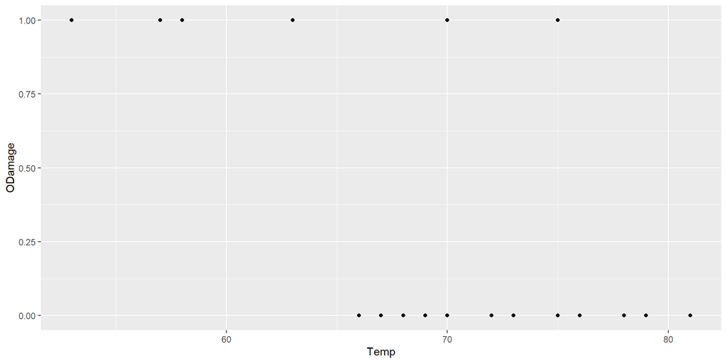

Does linear regression make sense? What does a residual mean here?

## New idea

We need a new way to define “best” for a model where least squares doesn’t work.

- In this chapter we introduce a method called maximum likelihood
- Maximum likelihood uses the idea (and function called) likelihood
- Maximum likelihood plays the same role that least squares played in regression with Normal error terms.

## What is the likelihood?

A **likelihood** is a function that tells us how likely we are to observe our data for a given parameter value (or values).

- Unlike Ordinary Least Squares (OLS), the likelihood does not require the responses to be independent, identically distributed, and normal (iidN)
- Likelihoods are **not** the same as probability functions
  - **Probability function:** Fixed parameter value(s). Input possible outcomes $\Rightarrow$ probability of seeing these outcomes given the parameter value(s)
  - **Likelihood:** Fixed data. Input possible parameter values $\Rightarrow$ probability of seeing the fixed data for that particular parameter value

## Fouls in college basketball games

The data set `04-refs.csv` includes 30 randomly selected NCAA men’s basketball games played in the 2009 - 2010 season.

We will focus on the variables `foul1`, `foul2`, and `foul3`, which indicate which team had a foul called them for the 1st, 2nd, and 3rd fouls, respectively.

- `H`: Foul was called on the home team
- `V`: Foul was called on the visiting team

We are focusing on the first three fouls for this analysis, but this could easily be extended to include all fouls in a game.

[The dataset was derived from `basektball0910.csv` used in [BMLR Section 11.2](https://bookdown.org/roback/bookdown-BeyondMLR/ch-GLMM.html#cs:refs)

## Fouls in college basketball games

```r
refs <- read_csv("data/04-refs.csv")
refs %>% slice(1:5) %>% kable()
```

| game | date | visitor | hometeam | foul1 | foul2 | foul3 |
| --- | --- | --- | --- | --- | --- | --- |
| 166 | 20100126 | CLEM | BC | V | V | V |
| 224 | 20100224 | DEPAUL | CIN | H | H | V |
| 317 | 20100109 | MARQET | NOVA | H | H | H |
| 214 | 20100228 | MARQET | SETON | V | V | H |
| 278 | 20100128 | SETON | SFL | H | V | V |

We will treat the games as independent in this analysis.

## Different likelihood models

**Model 1 (Unconditional Model)**: What is the probability the referees call a foul on the home team, assuming foul calls within a game are independent?

**Model 2 (Conditional Model)**:

- Is there a tendency for the referees to call more fouls on the visiting team or home team?
- Is there a tendency for referees to call a foul on the team that already has more fouls?

Ultimately we want to decide which model is better.

## Exploratory data analysis

```r
refs %>%
count(foul1, foul2, foul3) %>% kable()
```

| foul1 | foul2 | foul3 | n |
| --- | --- | --- | --- |
| H | H | H | 3 |
| H | H | V | 2 |
| H | V | H | 3 |
| H | V | V | 7 |
| V | H | H | 7 |
| V | H | V | 1 |
| V | V | H | 5 |
| V | V | V | 2 |

There are

- 46 total fouls on the home team
- 44 total fouls on the visiting team

## Model 1: Unconditional model

*What is the probability the referees call a foul on the home team, assuming foul calls within a game are independent?*

## Likelihood

Let $p_H$ be the probability the referees call a foul on the home team.

**The likelihood for a single observation**

$$Lik(p_H) = p_H^{y_i}(1 - p_H)^{n_i - y_i}$$

Where $y_i$ is the number of fouls called on the home team.

(In this example, we know $n_i = 3$ for all observations.)

**Example**

For a single game where the first three fouls are $H, H, V$, then

$$Lik(p_H) = p_H^{2}(1 - p_H)^{3 - 2} = p_H^{2}(1 - p_H)$$

## Model 1: Likelihood contribution

| Foul1 | Foul2 | Foul3 | n | Likelihood Contribution |
| --- | --- | --- | --- | --- |
| H | H | H | 3 | $p_H^3$ |
| H | H | V | 2 | $p_H^2(1 - p_H)$ |
| H | V | H | 3 | $p_H^2(1 - p_H)$ |
| H | V | V | 7 | A |
| V | H | H | 7 | B |
| V | H | V | 1 | $p_H(1 - p_H)^2$ |
| V | V | H | 5 | $p_H(1 - p_H)^2$ |
| V | V | V | 2 | $(1 - p_H)^3$ |

Fill in **A** and **B**.

## Model 1: Likelihood function

Because the observations (the games) are independent, the **likelihood** is

$$Lik(p_H) = \prod_{i=1}^{n}p_H^{y_i}(1 - p_H)^{3 - y_i}$$

We will use this function to find the **maximum likelihood estimate (MLE)**. The MLE is the value between 0 and 1 where we are most likely to see the observed data.

## Visualizing the likelihood

- Plot
- Code

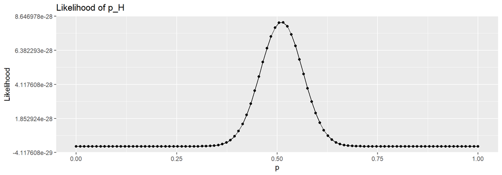

```r
p <- seq(0,1, length.out = 100) #sequence of 100 values between 0 and 100
lik <- p^46 *(1 -p)^44

x <- tibble(p = p, lik = lik)
ggplot(data = x, aes(x = p, y = lik)) +
  geom_point() +
  geom_line() +
  labs(y = "Likelihood",
       title = "Likelihood of p_H")
```

## Q: What is your best guess for the MLE, $\hat{p}_H$?

A. 0.489

B. 0.500

C. 0.511

D. 0.556

## Finding the maximum likelihood estimate

There are three primary ways to find the MLE

✅ Approximate using a graph

✅ Numerical approximation

✅ Using calculus

## Approximate MLE from a graph

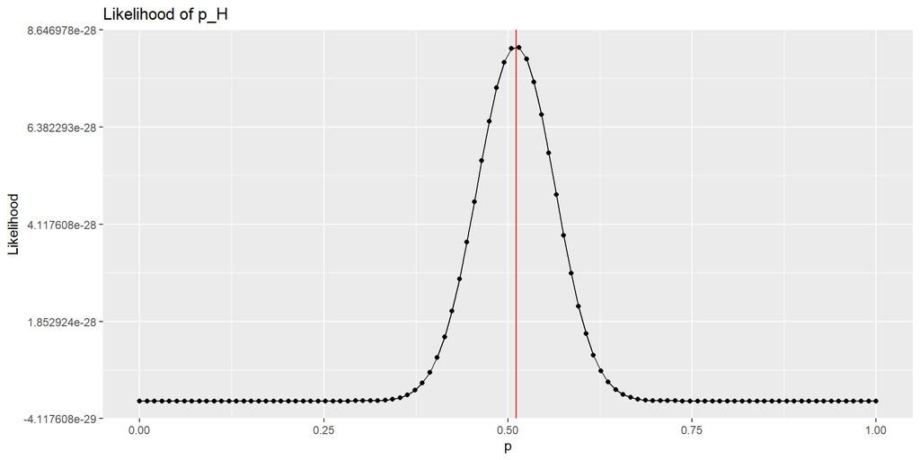

## Find the MLE using numerical approximation

Specify a finite set of possible values the for $p_H$ and calculate the likelihood for each value

```r
# write an R function for the likelihood
ref_lik <- function(ph) {
  ph^46 *(1 - ph)^44
}
```

```r
# use the optimize function to find the MLE
optimize(ref_lik, interval = c(0,1), maximum = TRUE)
```

```
$maximum
[1] 0.5111132

$objective
[1] 8.25947e-28
```

## Find MLE using calculus

- Find the MLE by taking the first derivative of the likelihood function.
- This can be tricky because of the Product Rule, so we can maximize the **log(Likelihood)** instead. The same value maximizes the likelihood and log(Likelihood)

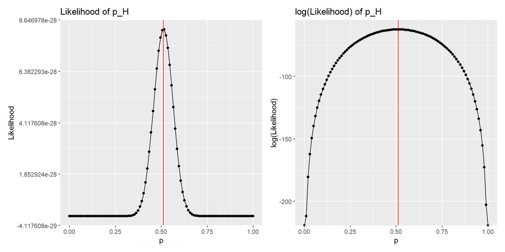

Since calculus is not a pre-req, we will forgo this quest. See STA 347/348.

## Model 2: Conditional model

- Is there a tendency for the referees to call more fouls on the visiting team or home team?
- Is there a tendency for referees to call a foul on the team that already has more fouls?

## Model 2: Likelihood contributions

- Now let’s assume fouls are **not** independent within each game. We will specify this dependence using conditional probabilities.
  - **Conditional probability**: $P(A|B) =$ Probability of $A$ given $B$ has occurred

Define new parameters:

- $p_{H|N}$: Probability referees call foul on home team given there are equal numbers of fouls on the home and visiting teams
- $p_{H|H Bias}$: Probability referees call foul on home team given there are more prior fouls on the home team
- $p_{H|V Bias}$: Probability referees call foul on home team given there are more prior fouls on the visiting team

## Model 2: Likelihood contributions

| Foul1 | Foul2 | Foul3 | n | Likelihood Contribution |
| --- | --- | --- | --- | --- |
| H | H | H | 3 | $(p_{H\vert N})(p_{H\vert H Bias})(p_{H\vert H Bias}) = (p_{H\vert N})(p_{H\vert H Bias})^2$ |
| H | H | V | 2 | $(p_{H\vert N})(p_{H\vert H Bias})(1 - p_{H\vert H Bias})$ |
| H | V | H | 3 | $(p_{H\vert N})(1 - p_{H\vert H Bias})(p_{H\vert N}) = (p_{H\vert N})^2(1 - p_{H\vert H Bias})$ |
| H | V | V | 7 | A |
| V | H | H | 7 | B |
| V | H | V | 1 | $(1 - p_{H\vert N})(p_{H\vert V Bias})(1 - p_{H\vert N}) = (1 - p_{H\vert N})^2(p_{H\vert V Bias})$ |
| V | V | H | 5 | $(1 - p_{H\vert N})(1-p_{H\vert V Bias})(p_{H\vert V Bias})$ |
| V | V | V | 2 | $\begin{aligned}&(1 - p_{H\vert N})(1-p_{H\vert V Bias})(1-p_{H\vert V Bias})\\ &=(1 - p_{H\vert N})(1-p_{H\vert V Bias})^2\end{aligned}$ |

Fill in **A** and **B**

## Likelihood function

$$\begin{aligned}Lik(p_{H| N}, p_{H|H Bias}, p_{H |V Bias}) &= [(p_{H| N})^{25}(1 - p_{H|N})^{23}(p_{H| H Bias})^8 \\ &(1 - p_{H| H Bias})^{12}(p_{H| V Bias})^{13}(1-p_{H|V Bias})^9]\end{aligned}$$

**(Note: The exponents sum to 90, the total number of fouls in the data)**

$$\begin{aligned}\log (Lik(p_{H| N}, p_{H|H Bias}, p_{H |V Bias})) &= 25 \log(p_{H| N}) + 23 \log(1 - p_{H|N}) \\ & + 8 \log(p_{H| H Bias}) + 12 \log(1 - p_{H| H Bias})\\ &+ 13 \log(p_{H| V Bias}) + 9 \log(1-p_{H|V Bias})\end{aligned}$$

## Q: If fouls within a game are independent, how would you expect $\hat{p}_H$, $\hat{p}_{H\vert H Bias}$ and $\hat{p}_{H\vert V Bias}$ to compare?

1. $\hat{p}_H$ is greater than $\hat{p}_{H\vert H Bias}$ and $\hat{p}_{H \vert V Bias}$
2. $\hat{p}_{H\vert H Bias}$ is greater than $\hat{p}_H$ and $\hat{p}_{H \vert V Bias}$
3. $\hat{p}_{H\vert V Bias}$ is greater than $\hat{p}_H$ and $\hat{p}_{H \vert V Bias}$
4. They are all approximately equal.

## Q: If there is a tendency for referees to call a foul on the team that already has more fouls, how would you expect $\hat{p}_H$ and $\hat{p}_{H\vert H Bias}$ to compare?

1. $\hat{p}_H$ is greater than $\hat{p}_{H\vert H Bias}$
2. $\hat{p}_{H\vert H Bias}$ is greater than $\hat{p}_H$
3. They are approximately equal.

## Likelihoods

**Model 1 (Unconditional Model)**

- $p_H$: probability of a foul being called on the home team

**Model 2 (Conditional Model)**

- $p_{H|N}$: Probability referees call foul on home team given there are equal numbers of fouls on the home and visiting teams
- $p_{H|H Bias}$: Probability referees call foul on home team given there are more prior fouls on the home team
- $p_{H|V Bias}$: Probability referees call foul on home team given there are more prior fouls on the visiting team

## Likelihoods

**Model 1 (Unconditional Model)**

$$Lik(p_H) = p_H^{46}(1 - p_H)^{44}$$

**Model 2 (Conditional Model)**

$$\begin{aligned}Lik(p_{H| N}, p_{H|H Bias}, p_{H |V Bias}) &= [(p_{H| N})^{25}(1 - p_{H|N})^{23}(p_{H| H Bias})^8 \\ &(1 - p_{H| H Bias})^{12}(p_{H| V Bias})^{13}(1-p_{H|V Bias})^9]\end{aligned}$$

## Maximum likelihood estimates

The **maximum likelihood estimate (MLE)** is the value between 0 and 1 where we are most likely to see the observed data.

**Model 1 (Unconditional Model)**

- $\hat{p}_H = 46/90 = 0.511$

. . .

**Model 2 (Conditional Model)**

- $\hat{p}_{H|N} = 25 / 48 = 0.521$
- $\hat{p}_{H|H Bias} = 8 /20 = 0.4$
- $\hat{p}_{H|V Bias} = 13/ 22 = 0.591$
- What is the probability the referees call a foul on the home team, assuming foul calls within a game are independent?
- Is there a tendency for the referees to call more fouls on the visiting team or home team?
- Is there a tendency for referees to call a foul on the team that already has more fouls?

## Finding the MLEs for model 2

The likelihood is

$$\begin{aligned}Lik(p_{H| N}, p_{H|H Bias}, p_{H |V Bias}) &= [(p_{H| N})^{25}(1 - p_{H|N})^{23}(p_{H| H Bias})^8 \\ &(1 - p_{H| H Bias})^{12}(p_{H| V Bias})^{13}(1-p_{H|V Bias})^9]\end{aligned}$$

The log-likelihood is

$$\begin{aligned}\log (Lik(p_{H| N}, p_{H|H Bias}, p_{H |V Bias})) &= 25 \log(p_{H| N}) + 23 \log(1 - p_{H|N}) \\ & + 8 \log(p_{H| H Bias}) + 12 \log(1 - p_{H| H Bias})\\ &+ 13 \log(p_{H| V Bias}) + 9 \log(1-p_{H|V Bias})\end{aligned}$$

We would like to find the MLEs for $p_{H| N}, p_{H|H Bias}, \text{ and }p_{H |V Bias}$.

## Finding MLEs using graphs

- We need to find the MLEs for three parameters, therefore we would need to visualize a 4-dimensional object to find the MLEs from a graph. Given the difficulty of this task and the lack of precision in the estimates from this approach, we should rely on other approaches to find the MLEs in this instance.
- We also can’t use calculus… that leaves only 1 approach…. optimization via grid search or *optim* in R

## Finding the MLEs using R (1/3)

We can write a function and do a grid search to find the values that maximize the log-likelihood.

```r
maxloglik<- function(nvals){
  #nvals specifies the number of values
  phn <- seq(0, 1, length = nvals)
  phh <- seq(0, 1, length = nvals)
  phv <- seq(0, 1, length = nvals)

  loglik <- expand.grid(phn, phh, phv)
  colnames(loglik) <- c("phn", "phh", "phv")

  loglik <- loglik %>%
    mutate(loglik  = log(phn^25 * (1 - phn)^23 * phh^8 * (1 - phh)^12 *
                           phv^13 * (1 - phv)^9))

  loglik %>%
    arrange(desc(loglik)) %>%
    slice(1)
}
```

```r
maxloglik(100)
```

```
        phn       phh       phv    loglik
1 0.5252525 0.4040404 0.5858586 -61.57691
```

## Finding the MLEs using R (2/3)

- Depending on the number of parameters, it may be hard to conduct a granular enough search to find the exact values of the MLEs.
- Therefore, one could use the function above to conduct a crude search to find starting values for R’s `optim` function.
- The function `optim` differs from `optimize` in that it can optimize over multiple parameter values (The `optimize` function can only optimize over a single parameter value).

```r
# Function to calculate log-likelihood that will be used in the optim function
loglik <- function(params){
  phn <- params[1]
  phh <- params[2]
  phv <- params[3]

  log(phn^25 * (1 - phn)^23 * phh^8 * (1 - phh)^12 *
                           phv^13 * (1 - phv)^9)
}
```

## Finding the MLEs using R (3/3)

```r
# use manual search to get starting values
start_vals <- maxloglik(50) %>% select(-loglik)
```

```r
# Use optim function in R to find the values to maximize the log-likelihood
#set fnscale = -1 to maximize (the default is minimize)
optim(par = start_vals, fn = loglik, control=list(fnscale=-1))
```

```
$par
      phn       phh       phv
0.5208272 0.4000361 0.5909793

$value
[1] -61.57319

$counts
function gradient
      66       NA

$convergence
[1] 0

$message
NULL
```

# Model Comparisons

## Model comparisons

- Nested models
- Non-nested models

## Nested Models (1/2)

**Nested models**: Models such that the parameters of the reduced model are a subset of the parameters for a larger model

Example:

$$\begin{aligned}&\text{Model A: }y = \beta_0 + \beta_1 x_1 + \beta_2 x_2 + \epsilon\\
&\text{Model B: }y = \beta_0 + \beta_1 x_1 + \beta_2 x_2 + \beta_3 x_3 + \beta_4 x_4 + \epsilon\end{aligned}$$

Model A is nested in Model B. We could use likelihoods to test whether it is useful to add $x_3$ and $x_4$ to the model.

$$\begin{aligned}&H_0: \beta_3 = \beta_4 = 0 \\
&H_a: \text{ at least one }\beta_j \text{ is not equal to 0}\end{aligned}$$

## Nested models (2/2)

**Another way to think about nested models**: Parameters in larger model can be equated to get the simpler model or if some parameters can be set to constants

Example:

$$\begin{aligned}&\text{Model 1: }p_H \\
&\text{Model 2: }p_{H| N}, p_{H| H Bias}, p_{H| V Bias}\end{aligned}$$

Model 1 is nested in Model 2. The parameters $p_{H| N}$, $p_{H|H Bias}$, and $p_{H |V Bias}$ can be set equal to $p_H$ to get Model 1.

$$\begin{aligned}&H_0: p_{H| N} = p_{H| H Bias} = p_{H| V Bias} = p_H \\
&H_a: \text{At least one of }p_{H| N}, p_{H| H Bias}, p_{H| V Bias} \text{ differs from the others}\end{aligned}$$

## Steps to compare models

1️⃣ Find the MLEs for each model.

2️⃣ Plug the MLEs into the log-likelihood function for each model to get the maximum value of the log-likelihood for each model.

3️⃣ Find the difference in the maximum log-likelihoods

4️⃣ Use the Likelihood Ratio Test to determine if the difference is statistically significant

## Steps 1 - 2

Find the MLEs for each model and plug them into the log-likelihood functions.

**Model 1:**

$\hat{p}_H = 46/90 = 0.511$

```r
loglik1 <- function(ph){
 log(ph^46 * (1 - ph)^44)
}
loglik1(46/90)
```

```
[1] -62.36102
```

**Model 2**

- $\hat{p}_{H|N} = 25 / 48 = 0.521$
- $\hat{p}_{H|H Bias} = 8 /20 = 0.4$
- $\hat{p}_{H|V Bias} = 13/ 22 = 0.591$

```r
loglik2 <- function(phn, phh, phv) {
  log(phn^25 * (1 - phn)^23 * phh^8 *
        (1 - phh)^12 * phv^13 * (1 - phv)^9)
}
loglik2(25/48, 8/20, 13/22)
```

```
[1] -61.57319
```

## Step 3

Find the difference in the log-likelihoods

```r
(diff <- loglik2(25/48, 8/20, 13/22) - loglik1(46/90))
```

```
[1] 0.7878318
```

**Is the difference in the maximum log-likelihoods statistically significant?**

## Likelihood Ratio Test

**Test statistic**

$$\begin{aligned} LRT &= 2[\max\{\log(Lik(\text{larger model}))\} - \max\{\log(Lik(\text{reduced model}))\}]\\[10pt]
&= 2\log\Bigg(\frac{\max\{(Lik(\text{larger model})\}}{\max\{(Lik(\text{reduced model})\}}\Bigg)\end{aligned}$$

LRT follows a $\chi^2$ distribution where the degrees of freedom equal the difference in the number of parameters between the two models

## Step 4

```r
(LRT <- 2 * (loglik2(25/48, 8/20, 13/22) - loglik1(46/90)))
```

```
[1] 1.575664
```

The test statistic follows a $\chi^2$ distribution with 2 degrees of freedom. Therefore, the p-value is $P(\chi^2 > LRT)$.

```r
pchisq(LRT, 2, lower.tail = FALSE)
```

```
[1] 0.4548299
```

The p-value is very large, so we fail to reject $H_0$. We do not have convincing evidence that the conditional model is an improvement over the unconditional model. Therefore, we can stick with the unconditional model.

## Comparing non-nested models

**AIC** = -2(max log-likelihood) + 2p

Unconditional Model

```r
(Model1_AIC <- 2 * loglik1(46/90) + 2 * 1)
```

```
[1] -122.722
```

Conditional Model

```r
(Model2_AIC <-2 * loglik2(25/48, 8/20, 13/22) + 2 * 3)
```

```
[1] -117.1464
```

**BIC** = -2(max log-likelihood) + plog(n)

Unconditional Model

```r
(Model1_BIC <- 2 * loglik1(46/90) + 1 * log(30))
```

```
[1] -121.3208
```

Conditional Model

```r
(Model2_BIC <-2 * loglik2(25/48, 8/20, 13/22) + 3 * log(30))
```

```
[1] -112.9428
```

**Choose Model 1, the unconditional model, based on AIC and BIC**

## Looking ahead

- Likelihoods help us answer the question of how likely we are to observe the data given different parameters
- In this example, we did not consider covariates, so in practice the parameters we want to estimate will look more similar to this

$$p_H = \frac{e^{\beta_0 + \beta_1x_1 + \dots + \beta_px_p}}{1 + e^{\beta_0 + \beta_1x_1 + \dots + \beta_px_p}}$$

- Finding the MLE becomes much more complex and numerical methods may be required.
  - We will primarily rely on software to find the MLE, but the conceptual ideas will be the same

## Acknowledgements

These slides are based on content in [BMLR: Chapter 2 - Beyond Least Squares: Using Likelihoods](https://bookdown.org/roback/bookdown-BeyondMLR/ch-beyondmost.html)

Initial versions of the slides are by Dr. Maria Tackett, Duke University

Original edits by Tyler George